# Agencja nieruchomości

grupaA

# Wstęp

## Opis problemu

Przedmiotem rozważań niniejszego opracowania są ceny wybranych nieruchomości. Celem badania jest wyselekcjonowanie czynników mogących istotnie wpływać na cenę domu. Narzędziem mającym to umożliwić będzie **model regresji**.

## Baza danych

Podstawą analizy jest baza danych nieruchomości wystawionych na sprzedaż, dostępnych w pewnej agencji nieruchomości.

```r
# wczytanie danych
dane <- read.csv("agencja_nieruchomosci.csv")

# wyświetlenie pierwszych wierszy danych
kable(head(dane))
```

| price | area | bedrooms | bathrooms | stories | mainroad | guestroom | basement | hotwaterheating | airconditioning | parking | prefarea | furnishingstatus |
| --- | --- | --- | --- | --- | --- | --- | --- | --- | --- | --- | --- | --- |
| 13300000 | 7420 | 4 | 2 | 3 | yes | no | no | no | yes | 2 | yes | furnished |
| 12250000 | 8960 | 4 | 4 | 4 | yes | no | no | no | yes | 3 | no | furnished |
| 12250000 | 9960 | 3 | 2 | 2 | yes | no | yes | no | no | 2 | yes | semi-furnished |
| 12215000 | 7500 | 4 | 2 | 2 | yes | no | yes | no | yes | 3 | yes | furnished |
| 11410000 | 7420 | 4 | 1 | 2 | yes | yes | yes | no | yes | 2 | no | furnished |
| 10850000 | 7500 | 3 | 3 | 1 | yes | no | yes | no | yes | 2 | yes | semi-furnished |

## Zmienne

Zmienną objaśnianą jest zmienna:

- **price** - cena nieruchomości w dolarach

Zmienne objaśniające to parametry techniczne danej nieruchomości:

- **area** - całkowita powierzchnia domu w stopach kwadratowych
- **bedrooms** - liczba sypialni w domu
- **bathrooms** - liczba łazienek w domu
- **stories** - liczba pięter w domu
- **mainroad** - czy dom jest połączony z główną drogą (Tak/Nie)
- **guestroom** - czy dom posiada pokój gościnny (Tak/Nie)
- **basement** - czy dom jest podpiwniczony (Tak/Nie)
- **hotwaterheating** - czy dom posiada system ogrzewania ciepłej wody (Tak/Nie)
- **airconditioning** - czy dom posiada system klimatyzacji (Tak/Nie)
- **parking** - liczba miejsc parkingowych dostępnych w budynku
- **prefarea** - czy dom znajduje się w preferowanym obszarze (Tak/Nie)
- **furnishingstatus** - status umeblowania domu (w pełni umeblowany, częściowo umeblowany, nieumeblowany)

```r
# wymiary bazy danych
dim(dane)
```

```
## [1] 545  13
```

# Przygotowanie danych

Rozpoczynamy od sprawdzenia poprawności danych i dokowania ewentualnych poprawek. W pierwszym kroku sprawdzamy czy w bazie występują jakieś braki danych.

```r
# ilość braków danych dla poszczególnych zmiennych
data.frame(braki = sapply(dane, function(x) sum(is.na(x))))
```

```
##                  braki
## price                0
## area                 0
## bedrooms             0
## bathrooms            0
## stories              0
## mainroad             0
## guestroom            0
## basement             0
## hotwaterheating      0
## airconditioning      0
## parking              0
## prefarea             0
## furnishingstatus     0
```

Nie ma żadnych braków danych. Sprawdźmy dalej jaki jest zakres osiąganych wartości dla zmiennych ilościowych.

```r
# zakres osiąganych wartości dla zmiennych ilościowych
describe(dane[,c(1:5,11)])[8:9]
```

```
##               min      max
## price     1750000 13300000
## area         1650    16200
## bedrooms        1        6
## bathrooms       1        4
## stories         1        4
## parking         0        3
```

Jak widać ceny osiągają tu milionowe wartości. Aby nie operować bardzo dużymi liczbami wyrazimy je w mln dolarów. Podobnie powierzchnię wyrazimy w tysiącach stóp kwadratowych.

```r
# przeliczenia wartości zmiennych price i area
dane <- dane %>%
  mutate(price = price/10^6,
         area = area/10^3)
```

# Analiza eksploracyjna

Przystępujemy do analizy struktury poszczególnych zmiennych. Dla zmiennych jakościowych sporządzamy wykres słupkowy rozkładu procentowego, dla zmiennych ilościowych obliczamy podstawowe miary rozkładu i sporządzamy histogram.

## Price

Cena to zmienna ilościowa.

```r
# statystyki opisowe
kable(describe(dane[,1])[c(2:5,8,9,11,12)])
```

|  | n | mean | sd | median | min | max | skew | kurtosis |
| --- | --- | --- | --- | --- | --- | --- | --- | --- |
| X1 | 545 | 4.766729 | 1.87044 | 4.34 | 1.75 | 13.3 | 1.205574 | 1.913125 |

Średnia cena badanych nieruchomości to 4,77 mln dolarów, przy czym ceny poszczególnych domów różnią się od średniej przeciętnie o 1,87 mln dolarów. Dla połowy nieruchomości cena nie przekracza 4,34 mln dolarów. Najniższa zaobserwowana wartość to 1,75, a najwyższa aż 13,3 mln dolarów. W rozkładzie występuje skrajna asymetria prawostronna, jest on też wyższy i smuklejszy od rozkładu normalnego.

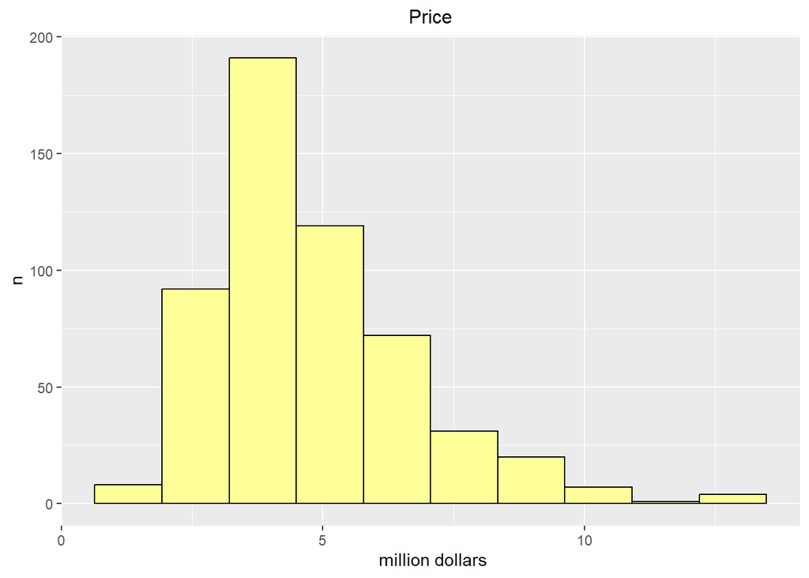

```r
# histogram
ggplot(dane, aes(x = price)) +
  geom_histogram(colour = "black", fill = "#FFFF99", bins = 10) +
  labs(title = "Price",
       x = " million dollars", y = "n") +
  theme(plot.title = element_text(hjust = 0.5, size = 12))
```

W rozkładzie dobrze widoczna jest asymetria prawostronna (wydłużona ramię z prawej strony).

Aby nie tworzyć oddzielnej tabeli i wykresu dla każdej zmiennej objaśniającej rozpatrzymy je wspólnie.

## Ilościowe zmienne objaśniające

```r
# statystyki opisowe
kable(describe(dane[,c(2:5,11)])[c(2:5,8,9,11,12)])
```

|  | n | mean | sd | median | min | max | skew | kurtosis |
| --- | --- | --- | --- | --- | --- | --- | --- | --- |
| area | 545 | 5.150541 | 2.1701410 | 4.6 | 1.65 | 16.2 | 1.3139246 | 2.6943586 |
| bedrooms | 545 | 2.965138 | 0.7380639 | 3.0 | 1.00 | 6.0 | 0.4929587 | 0.6970645 |
| bathrooms | 545 | 1.286239 | 0.5024696 | 1.0 | 1.00 | 4.0 | 1.5805260 | 2.1152340 |
| stories | 545 | 1.805505 | 0.8674925 | 2.0 | 1.00 | 4.0 | 1.0761391 | 0.6487711 |
| parking | 545 | 0.693578 | 0.8615858 | 0.0 | 0.00 | 3.0 | 0.8374328 | -0.5876845 |

Wyniki interpretuje się analogicznie jak w przypadku ceny.

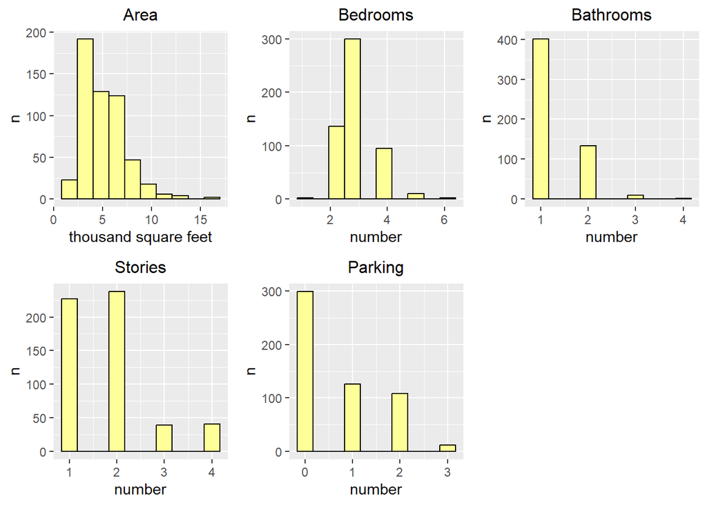

```r
# histogramy
plot1 <- ggplot(dane, aes(x = area)) +
  geom_histogram(colour = "black", fill = "#FFFF99", bins = 10) +
  labs(title = "Area",
       x = "thousand square feet", y = "n") +
  theme(plot.title = element_text(hjust = 0.5, size = 12))

plot2 <- ggplot(dane, aes(x = bedrooms)) +
  geom_histogram(colour = "black", fill = "#FFFF99", bins = 10) +
  labs(title = "Bedrooms",
       x = "number", y = "n") +
  theme(plot.title = element_text(hjust = 0.5, size = 12))

plot3 <- ggplot(dane, aes(x = bathrooms)) +
  geom_histogram(colour = "black", fill = "#FFFF99", bins = 10) +
  labs(title = "Bathrooms",
       x = "number", y = "n") +
  theme(plot.title = element_text(hjust = 0.5, size = 12))

plot4 <- ggplot(dane, aes(x = stories)) +
  geom_histogram(colour = "black", fill = "#FFFF99", bins = 10) +
  labs(title = "Stories",
       x = "number", y = "n") +
  theme(plot.title = element_text(hjust = 0.5, size = 12))

plot5 <- ggplot(dane, aes(x = parking)) +
  geom_histogram(colour = "black", fill = "#FFFF99", bins = 10) +
  labs(title = "Parking",
       x = "number", y = "n") +
  theme(plot.title = element_text(hjust = 0.5, size = 12))

grid.arrange(plot1, plot2, plot3, plot4, plot5, nrow = 2)
```

W przypadku powierzchni również mamy asymetrię prawostronną. Pozostałe zmienne to zmienne skokowe (przyjmujące tylko całkowite wartości), przy tak małym zakresie osiąganych wartości można je też potraktować jak zmienne jakościowe.

## Jakościowe zmienne objaśniające

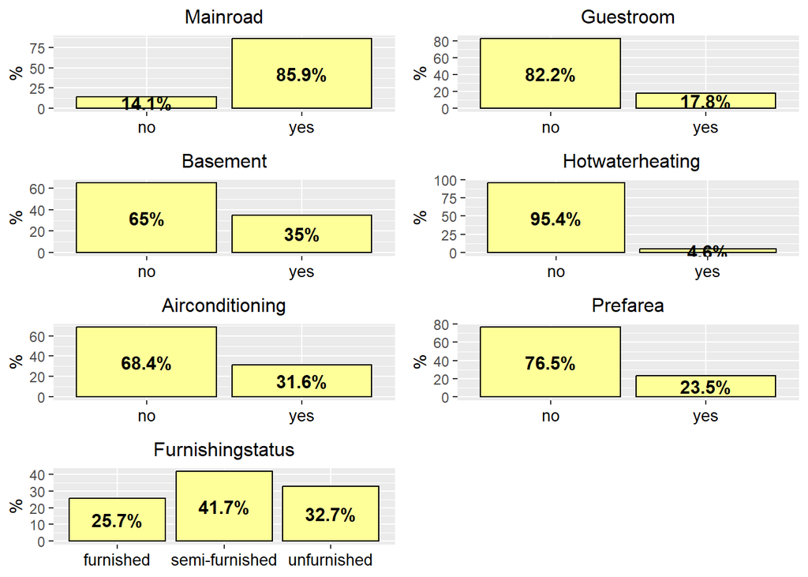

```r
# wykres słupkowy dla zmiennej mainroad
tab <- as.data.frame(100*prop.table(table(dane$mainroad)))
plot1 <- ggplot(tab, aes(x = Var1, y = Freq)) +
  geom_col(fill = "#FFFF99", colour = "black") +
  geom_text(aes(label = paste0(round(Freq,1),"%")),
            stat = "identity", size = 4,
            fontface = "bold", position = position_stack(vjust = 0.5)) +
  theme(axis.title.x = element_blank(),
        axis.text.x = element_text(colour = "black", size = 10),
        plot.title = element_text(hjust = 0.5, size = 12)) +
  labs(title = "Mainroad",
       y = "%")

# wykres słupkowy dla zmiennej guestroom
tab <- as.data.frame(100*prop.table(table(dane$guestroom)))
plot2 <- ggplot(tab, aes(x = Var1, y = Freq)) +
  geom_col(fill = "#FFFF99", colour = "black") +
  geom_text(aes(label = paste0(round(Freq,1),"%")),
            stat = "identity", size = 4,
            fontface = "bold", position = position_stack(vjust = 0.5)) +
  theme(axis.title.x = element_blank(),
        axis.text.x = element_text(colour = "black", size = 10),
        plot.title = element_text(hjust = 0.5, size = 12)) +
  labs(title = "Guestroom",
       y = "%")

# wykres słupkowy dla zmiennej basement
tab <- as.data.frame(100*prop.table(table(dane$basement)))
plot3 <- ggplot(tab, aes(x = Var1, y = Freq)) +
  geom_col(fill = "#FFFF99", colour = "black") +
  geom_text(aes(label = paste0(round(Freq,1),"%")),
            stat = "identity", size = 4,
            fontface = "bold", position = position_stack(vjust = 0.5)) +
  theme(axis.title.x = element_blank(),
        axis.text.x = element_text(colour = "black", size = 10),
        plot.title = element_text(hjust = 0.5, size = 12)) +
  labs(title = "Basement",
       y = "%")

# wykres słupkowy dla zmiennej hotwaterheating
tab <- as.data.frame(100*prop.table(table(dane$hotwaterheating)))
plot4 <- ggplot(tab, aes(x = Var1, y = Freq)) +
  geom_col(fill = "#FFFF99", colour = "black") +
  geom_text(aes(label = paste0(round(Freq,1),"%")),
            stat = "identity", size = 4,
            fontface = "bold", position = position_stack(vjust = 0.5)) +
  theme(axis.title.x = element_blank(),
        axis.text.x = element_text(colour = "black", size = 10),
        plot.title = element_text(hjust = 0.5, size = 12)) +
  labs(title = "Hotwaterheating",
       y = "%")

# wykres słupkowy dla zmiennej airconditioning
tab <- as.data.frame(100*prop.table(table(dane$airconditioning)))
plot5 <- ggplot(tab, aes(x = Var1, y = Freq)) +
  geom_col(fill = "#FFFF99", colour = "black") +
  geom_text(aes(label = paste0(round(Freq,1),"%")),
            stat = "identity", size = 4,
            fontface = "bold", position = position_stack(vjust = 0.5)) +
  theme(axis.title.x = element_blank(),
        axis.text.x = element_text(colour = "black", size = 10),
        plot.title = element_text(hjust = 0.5, size = 12)) +
  labs(title = "Airconditioning",
       y = "%")

# wykres słupkowy dla zmiennej prefarea
tab <- as.data.frame(100*prop.table(table(dane$prefarea)))
plot6 <- ggplot(tab, aes(x = Var1, y = Freq)) +
  geom_col(fill = "#FFFF99", colour = "black") +
  geom_text(aes(label = paste0(round(Freq,1),"%")),
            stat = "identity", size = 4,
            fontface = "bold", position = position_stack(vjust = 0.5)) +
  theme(axis.title.x = element_blank(),
        axis.text.x = element_text(colour = "black", size = 10),
        plot.title = element_text(hjust = 0.5, size = 12)) +
  labs(title = "Prefarea",
       y = "%")

# wykres słupkowy dla zmiennej furnishingstatus
tab <- as.data.frame(100*prop.table(table(dane$furnishingstatus)))
plot7 <- ggplot(tab, aes(x = Var1, y = Freq)) +
  geom_col(fill = "#FFFF99", colour = "black") +
  geom_text(aes(label = paste0(round(Freq,1),"%")),
            stat = "identity", size = 4,
            fontface = "bold", position = position_stack(vjust = 0.5)) +
  theme(axis.title.x = element_blank(),
        axis.text.x = element_text(colour = "black", size = 10),
        plot.title = element_text(hjust = 0.5, size = 12)) +
  labs(title = "Furnishingstatus",
       y = "%")

# wykres wspólny
grid.arrange(plot1, plot2, plot3, plot4, plot5, plot6, plot7, nrow = 4)
```

Mamy duże dysproporcje w rozkładzie kategorii poszczególnych zmiennych.

# Model regresji

Wybierając postać funkcyjną modelu regresji rozpoczyna się od oceny wzrokowej charakteru zależności między zmiennymi objaśniającymi, a zmienną objaśnianą. Sporządza się wykresy rozrzutu. Tutaj taki wykres można zrobić tylko dla pary area-price.

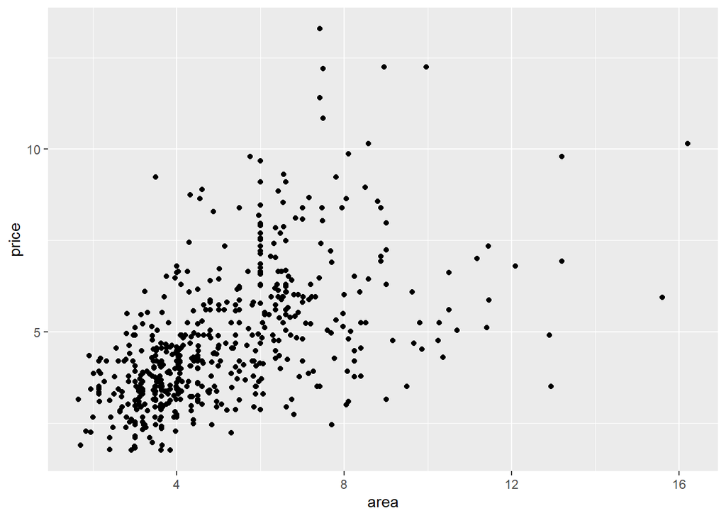

```r
# wykres rozrzutu
ggplot(dane, aes(x = area, y = price)) +
geom_point()
```

Mamy tutaj zależność dodatnią, czym większa powierzchnia domu, tym wyższa cena. Jednak układ punktów nie wskazuje na ściśły związek liniowy. Ponieważ jednak nie ma tu też zależności nieliniowej, więc szacujemy model regresji liniowej, czyli najprostszy model funkcyjny dopasowany do danych.

```r
# model regresji
model <- lm(price ~ ., data = dane)
summary(model)
```

```
##
## Call:
## lm(formula = price ~ ., data = dane)
##
## Residuals:
##     Min      1Q  Median      3Q     Max
## -2.6197 -0.6573 -0.0684  0.5072  5.1667
##
## Coefficients:
##                                Estimate Std. Error t value Pr(>|t|)
## (Intercept)                     0.04277    0.26431   0.162 0.871508
## area                            0.24414    0.02429  10.052  < 2e-16 ***
## bedrooms                        0.11479    0.07260   1.581 0.114445
## bathrooms                       0.98767    0.10336   9.555  < 2e-16 ***
## stories                         0.45085    0.06417   7.026 6.55e-12 ***
## mainroadyes                     0.42127    0.14222   2.962 0.003193 **
## guestroomyes                    0.30053    0.13171   2.282 0.022901 *
## basementyes                     0.35011    0.11028   3.175 0.001587 **
## hotwaterheatingyes              0.85545    0.22315   3.833 0.000141 ***
## airconditioningyes              0.86496    0.10835   7.983 8.91e-15 ***
## parking                         0.27711    0.05853   4.735 2.82e-06 ***
## prefareayes                     0.65154    0.11568   5.632 2.89e-08 ***
## furnishingstatussemi-furnished -0.04634    0.11657  -0.398 0.691118
## furnishingstatusunfurnished    -0.41123    0.12621  -3.258 0.001192 **
## ---
## Signif. codes:  0 '***' 0.001 '**' 0.01 '*' 0.05 '.' 0.1 ' ' 1
##
## Residual standard error: 1.068 on 531 degrees of freedom
## Multiple R-squared:  0.6818, Adjusted R-squared:  0.674
## F-statistic: 87.52 on 13 and 531 DF,  p-value: < 2.2e-16
```

W przypadku ilościowych zmiennych objaśniających parametr strukturalny (kolumna Estimate) określa jak zmieni się cena, gdy dana zmienna wzrośnie o jednostkę, przy niezmienionych wartościach pozostałych zmiennych. Przykładowo powierzchnia domu większa o 1 tys. stóp kwadratowych, to cena większa przeciętnie o 0,24 mln dolarów.

W przypadku zmiennych jakościowych mamy odniesienie do poziomu referencyjnego. Przykładowo dla zmiennej mainroad poziomem referencyjnym jest “no”, współczynnik 0.42127 dla kategorii “yes” oznacza, że dla domu połączonego z główną drogą cena jest przeciętnie o 0,42 mln dolarów większa niż dla domów bez takiego połączenia.

Dla wszystkich zmiennych poza furnishingstatus kategorią referencyjną jest “no” (dla furnishingstatus jest to “furnished”, czyli pierwsza kategoria).

Wpływ zmiennej bedrooms na cenę okazał się nieistotny statystycznie (p>0,05 dla testu t-Studenta), powinna ona zostać wyłączona z modelu, a ten oszacowany ponownie. Podobnie sytuacja ma się z jedną z kategorii zmiennej furnishingstatus, jednak tą zmienną należy traktować jako całość, nie da się sensownie wyłączyć tylko jednej kategorii.

Łącznie wpływ wszystkich zmiennych objaśniających na zmienną objaśnianą jest istotny statystycznie (p<0,05 dla testu F).

W powyższym modelu użyte zostały wszystkie dostępne zmienne objaśniające. Może powstać pytanie, czy jest to optymalny zestaw zmiennych. Ten możemy określić stosując metodę krokową doboru zmiennych (minimalizując wartość AIC).

```r
# metoda krokowa doboru zmiennych
stepAIC(model, direction = "both")
```

```
## Start:  AIC=85.46
## price ~ area + bedrooms + bathrooms + stories + mainroad + guestroom +
##     basement + hotwaterheating + airconditioning + parking +
##     prefarea + furnishingstatus
##
##                    Df Sum of Sq    RSS     AIC
## <none>                          605.60  85.459
## - bedrooms          1     2.851 608.45  86.019
## - guestroom         1     5.938 611.53  88.777
## - mainroad          1    10.006 615.60  92.390
## - basement          1    11.494 617.09  93.706
## - furnishingstatus  2    16.379 621.98  96.003
## - hotwaterheating   1    16.760 622.36  98.337
## - parking           1    25.568 631.16 105.996
## - prefarea          1    36.178 641.78 115.081
## - stories           1    56.299 661.90 131.906
## - airconditioning   1    72.675 678.27 145.226
## - bathrooms         1   104.133 709.73 169.934
## - area              1   115.227 720.82 178.387
```

```
##
## Call:
## lm(formula = price ~ area + bedrooms + bathrooms + stories +
##     mainroad + guestroom + basement + hotwaterheating + airconditioning +
##     parking + prefarea + furnishingstatus, data = dane)
##
## Coefficients:
##                    (Intercept)                            area                        bedrooms                       bathrooms
##                        0.04277                         0.24414                         0.11479                         0.98767
##                        stories                     mainroadyes                    guestroomyes                     basementyes
##                        0.45085                         0.42127                         0.30053                         0.35011
##             hotwaterheatingyes              airconditioningyes                         parking                     prefareayes
##                        0.85545                         0.86496                         0.27711                         0.65154
## furnishingstatussemi-furnished     furnishingstatusunfurnished
##                       -0.04634                        -0.41123
```

Jak się okazuje jest to model optymalny.

Wszystkie zmienne poza furnishingstatus dodatnio wpływają na cenę. Czym większa powierzchnia, liczba łazienek, dostępnośc piwnicy itp., tym oczywiście wyższa cena domu. Jedyne ujemne parametry dotyczą zmiennej furnishingstatus, ale jest to związane z użytymi kategoriami. Kategorią referencyjną jest tutaj “furnished”, więc domy tylko częściowo umeblowane, lub nieumeblowane wcale osiągają niższą cenę, niż te w pełni umeblowane.

Model wyjaśnia zmienność ceny w 68,18%, dopasowanie do danych jest umiarkowane.

Modelu możemy oczywiście użyć następnie do prognozowania, np. do wyznaczenia ceny domu o interesujących nas parametrach.

```r
# prognoza
predict(model, data.frame(area = 1,
                          bedrooms = 1,
                          bathrooms = 1,
                          stories = 1,
                          mainroad = "no",
                          guestroom = "no",
                          basement = "no",
                          hotwaterheating = "no",
                          airconditioning = "no",
                          parking = 0,
                          prefarea = "no",
                          furnishingstatus = "unfurnished"))
```

```
##       1
## 1.42898
```

Powyżej wyceniony został dom o najskromniejszych możliwych parametrach. Jego cena to 1,43 mln dolarów.

# Podsumowanie

Przeprowadzona analiza dostarczyła dużo informacji o domach dostępnych w ofercie pewnej agencji nieruchomości. Zbudowany model ekonometryczny może być pomocnym narzędziem umożliwiającym wycenę takich obiektów.